# Data Visualization with ggplot2

## Warm Up (with a neighbor)

Here are the first few rows of a data set with information about participants in a randomized controlled trial designed to evaluate a substance abuse treatment program. What are the observational units and variables? Are the variables categorical or quantitative?

```r
head(HELPrct)
```

```
##   age homeless substance dep_score mental_score
## 1  37   housed   cocaine        49    25.111990
## 2  37 homeless   alcohol        30    26.670307
## 3  26   housed    heroin        39     6.762923
## 4  39   housed    heroin        15    43.967880
## 5  32 homeless   cocaine        39    21.675755
## 6  47   housed   cocaine         6    55.508991
```

## 5 Main Plots (for this class)

1. Bar: Categorical

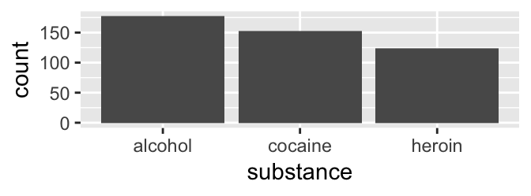

2. Histogram: Quantitative

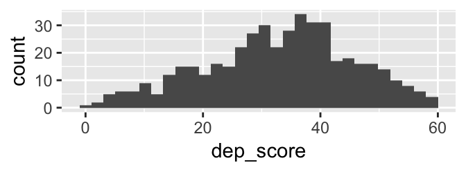

3. Density: Quantitative

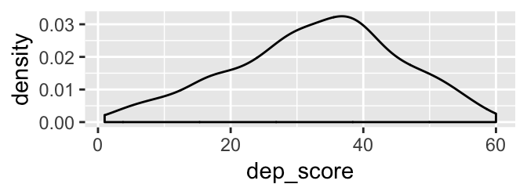

4. Boxplot: 1 Quantitative, 1 Categorical

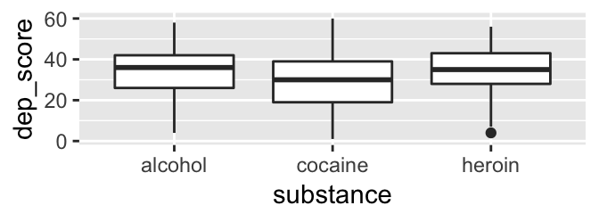

5. Scatterplot: 2 Quantitative

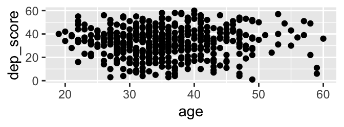

Also: color

## The Grammar of Graphics

A statistical graphic is a `mapping` of `data` variables to `aes()`thetic attributes of `geom_`etric objects

```r
ggplot(data = <data_frame>,
    mapping = aes(<attribute1> = <variable1>, <attribute2> = <variable2>),
  ) +
  geom_<geometry type>()
```

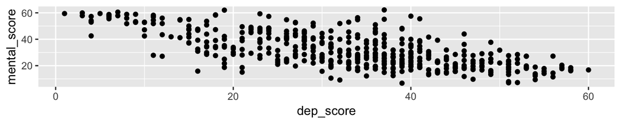

```r
ggplot(data = HELPrct,
    mapping = aes(x = dep_score, y = mental_score),
  ) +
  geom_point()
```

## What are the `geom_`etric objects?

1. `geom_bar`

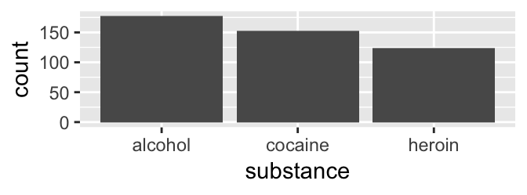

2. `geom_histogram`

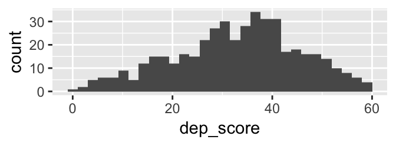

3. `geom_density`

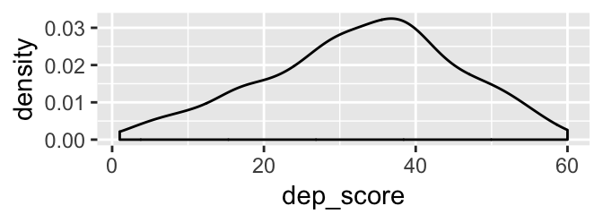

4. `geom_boxplot`

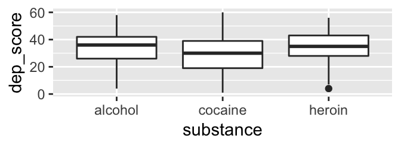

5. `geom_point`

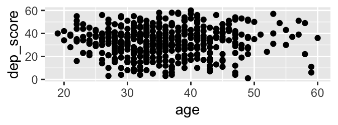

## What are the `aes`thetic properties?

1. `x` for horizontal axis (applicable for all geometry types)
2. `y` for vertical axis (applicable for plot types that have a variable on the vertical axis: boxplot and scatter plot)
3. `fill` (for fill color in geometric objects that have an internal area) or `color` (for color of objects that don't have an internal area)

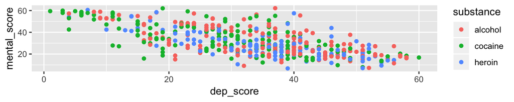

```r
ggplot(data = HELPrct,
    mapping = aes(x = dep_score, y = mental_score, color = substance),
  ) +
  geom_point()
```

## 1 Categorical Variable: Bar Plot

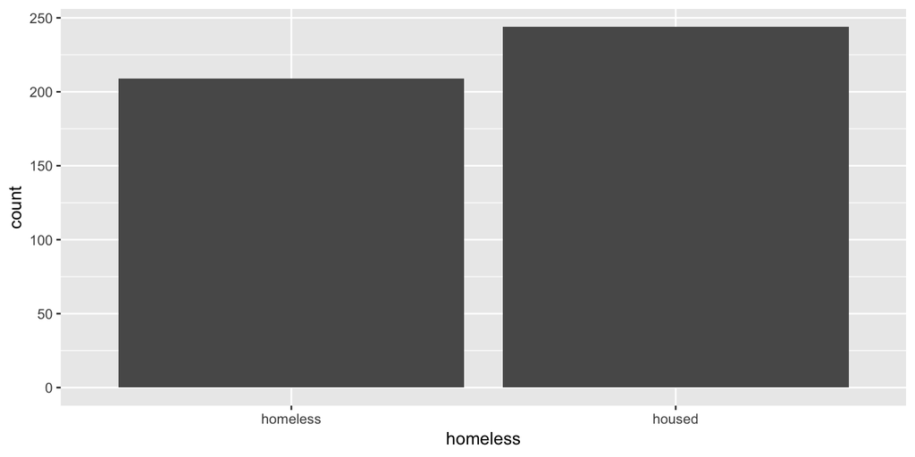

```r
ggplot(data = HELPrct,
    mapping = aes(x = homeless)
  ) +
  geom_bar()
```

## 2 Categorical Variables: Bar Plot

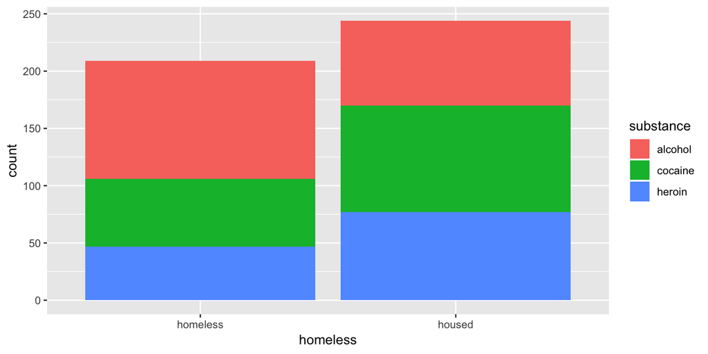

```r
ggplot(data = HELPrct,
    mapping = aes(x = homeless, fill = substance)
  ) +
  geom_bar()
```

## 2 Categorical Variables: Bar Plot

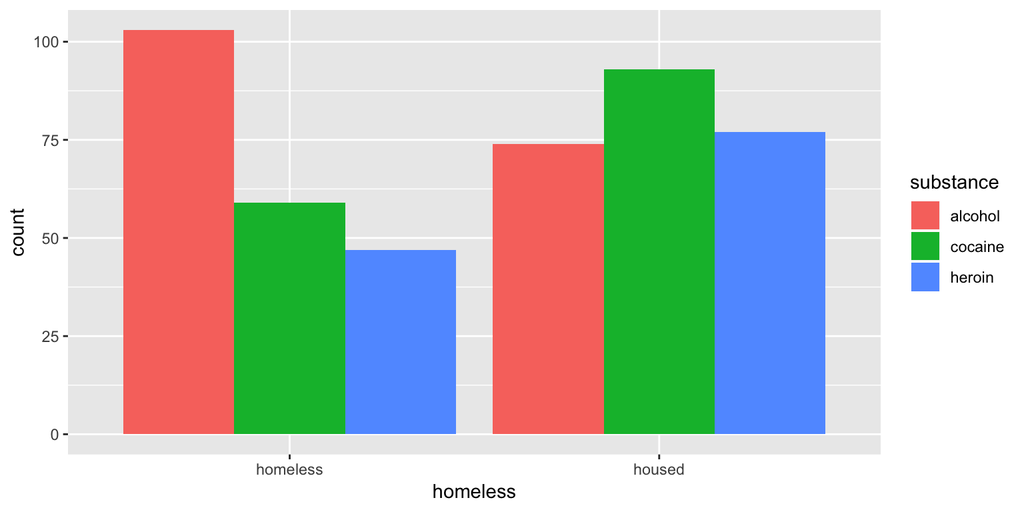

```r
ggplot(data = HELPrct,
    mapping = aes(x = homeless, fill = substance)
  ) +
  geom_bar(position = position_dodge())
```

## 1 Quantitative Variable: Histograms

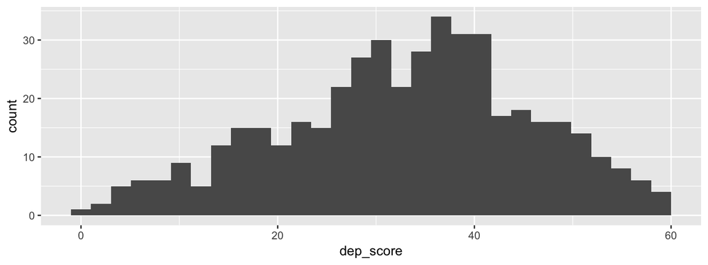

```r
ggplot(data = HELPrct,
    mapping = aes(x = dep_score),
  ) +
  geom_histogram()
```

## 1 Quantitative Variable: Histograms

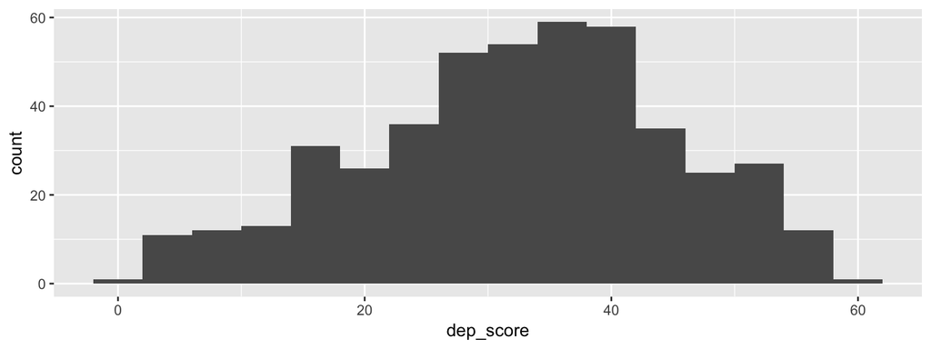

```r
ggplot(data = HELPrct,
    mapping = aes(x = dep_score),
  ) +
  geom_histogram(binwidth = 4)
```

## 1 Quantitative Variable: Density Plots

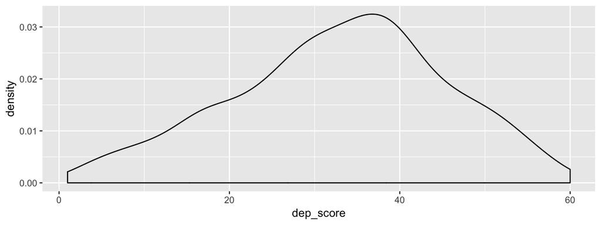

```r
ggplot(data = HELPrct,
    mapping = aes(x = dep_score),
  ) +
  geom_density()
```

## 2 Quantitative Variables: Scatter Plots

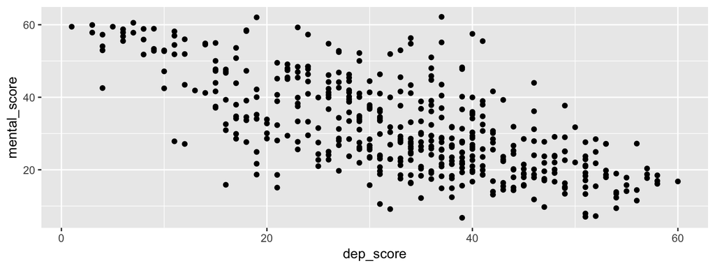

```r
ggplot(data = HELPrct,
    mapping = aes(x = dep_score, y = mental_score)
  ) +
  geom_point()
```

## 2 Quantitative Variables: Scatter Plots

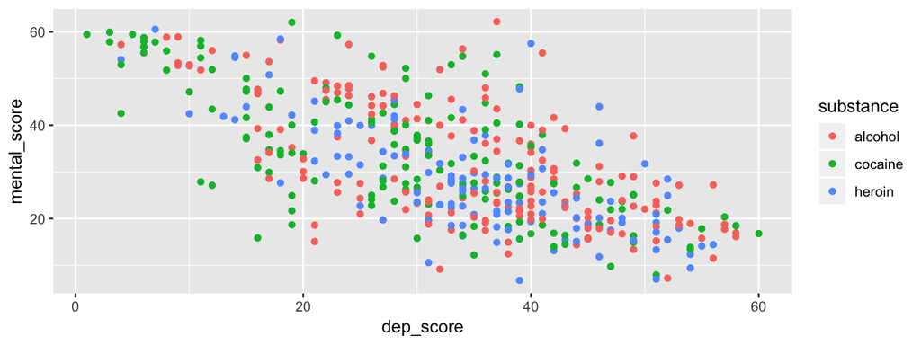

```r
ggplot(data = HELPrct,
    mapping = aes(x = dep_score, y = mental_score, color = substance)
  ) +
  geom_point()
```

## 1 Quantitative, 1 Categorical: Box Plots

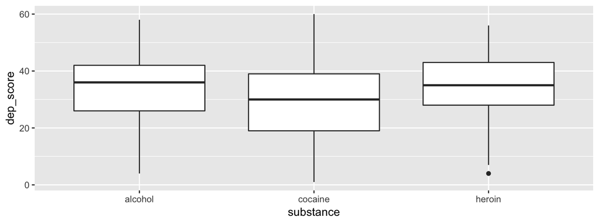

```r
ggplot(data = HELPrct,
    mapping = aes(x = substance, y = dep_score)
  ) +
  geom_boxplot()
```

## 1 Quantitative, 1 Categorical: Density

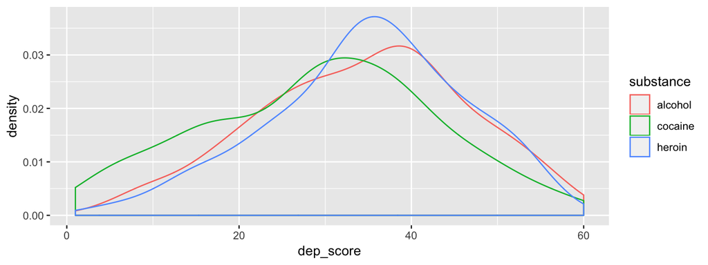

```r
ggplot(data = HELPrct,
    mapping = aes(x = dep_score, color = substance)
  ) +
  geom_density()
```

## Summary

| Variables | Plot Type | Geometry | Aesthetics |
| --- | --- | --- | --- |
| 1 Categorical | Bar Plot | geom_bar | x |
| 1 Quantitative | Histogram | geom_histogram | x |
| 1 Quantitative | Density | geom_density | x |
| 2 Categorical | Bar Plot | geom_bar | x, fill |
| 2 Quantitative | Scatter Plot | geom_point | x, y |
| 1 Categorical and 1 Quantitative | Box Plot | geom_boxplot | x (categorical), y (quantitative) |
| 1 Categorical and 1 Quantitative | Density Plot | geom_density | x (quantitative), color (categorical) |

## Common Error 1

No `+` after call to `ggplot()`:

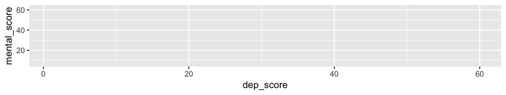

```r
ggplot(data = HELPrct,
    mapping = aes(x = dep_score, y = mental_score)
  )
```

```r
  geom_point()
```

```
## geom_point: na.rm = FALSE
## stat_identity: na.rm = FALSE
## position_identity
```

## Common Error 2

`%>%` instead of `+` after call to `ggplot()`:

```r
ggplot(data = HELPrct,
    mapping = aes(x = dep_score, y = mental_score)
  ) %>%
  geom_point()
```

**Error: Mapping must be created by `aes()` or `aes_()`**

## Common Error 3

Forgot `data =`:

```r
ggplot(mapping = aes(x = dep_score, y = mental_score)) +
  geom_point()
```

**Error in FUN(X[[i]], …) : object 'dep_score' not found**